# 多元统计学

# 主成分分析

主成分分析是利用随机向量中随机变量的相关性进行降维的方法。

## 模型与性质

模型假设：随机向量$\boldsymbol{X}=(X_1,X_2,\cdots,X_p)^T$中不存在相关系数的绝对值为$1$的一对变量。

模型：
$$Y_1=\beta_{11}X_1+\beta_{12}X_2+\cdots+\beta_{1p}X_p\\Y_2=\beta_{21}X_1+\beta_{22}X_2+\cdots+\beta_{2p}X_p\\\cdots\\Y_p=\beta_{p1}X_1+\beta_{p2}X_2+\cdots+\beta_{pp}X_p$$
，简记为
$$\boldsymbol{Y}=\boldsymbol{B}\boldsymbol{X}$$
，其中$\boldsymbol{B}=(\boldsymbol{\beta}^T_1,\boldsymbol{\beta}^T_2,\cdots,\boldsymbol{\beta}^T_p)$，$\boldsymbol{\beta}_i$是协方差矩阵$\boldsymbol{\sum}=Cov(\boldsymbol{X})$的$p$个单位正交化的特征向量，对应的特征值为$\lambda_i$。（当随机向量中的各个随机变量的量纲差别比较大时，建议使用相关矩阵）

性质：

1. $Var(Y_i)=\lambda_i,\ \ \ \ \ i=1,2,\cdots,p$。
2. $Cov(Y_i,Y_j)=0,\ \ \ \ \ 0\leq i<j\leq p$。
3. $\sum Var(X_i)=\sum\lambda_i$

## 方差贡献率与因子载荷量

主成分$Y_i$的方差贡献率：
$$\alpha_i=\frac{\lambda_i}{\sum\lambda_i}$$

方差贡献率是衡量主成分对随机向量$\boldsymbol{X}$的方差解释力的指标。通常而言，当前三个主成分的累计方差贡献率达到$85\%$，则说明主成分分析的效果良好。

主成分$Y_i$对变量$X_j$的因子载荷量（相关系数）：
$$Corr(Y_i,X_j)=\frac{\sqrt{\lambda_i}\beta_{ij}}{\sqrt{Var(X_j)}}$$

因子载荷量是衡量主成分$Y_i$对随机变量$X_i$的方差解释能力的指标。它具有如下性质：

1. $\sum_{j=1}^pCov(Y_i,X_j)=\lambda_i$
2. $\sum_{i=1}^p\big{[}Corr(Y_i,X_j)\big{]}^2=1$

## 模型检验

若至少存在一对变量的线性相关系数的绝对值接近$1$，则会导致最小的特征值$\lambda_p$接近0。因此当$\lambda_p$的值接近$0$时需谨慎。

# R型因子分析

因子分析是从随机向量中寻找少数本质因子的方法。与主成分分析方法非常相似。

## 模型假设与性质

假设：
$$X_1=\alpha_{11}F_1+\alpha_{12}F_2+\cdots+\alpha_{1m}F_m+\varepsilon_1\\X_2=\alpha_{21}F_1+\alpha_{22}F_2+\cdots+\alpha_{2m}F_m+\varepsilon_2\\\cdots\\X_p=\alpha_{p1}F_1+\alpha_{p2}F_2+\cdots+\alpha_{pm}F_m+\varepsilon_p$$
，其中：

1. $m<p$
2. $E(X_i)=0,Var(X_i)=1,\ \ \ \ i=1,\cdots,p$
3. $E(\boldsymbol{F})=\boldsymbol{0},Cov(\boldsymbol{F})=\boldsymbol{E}$
4. $E(\boldsymbol{\varepsilon})=\boldsymbol{0},Cov(\boldsymbol{\varepsilon})=diag(\sigma_1^2,\cdots,\sigma^2_p)$
5. $Cov(\boldsymbol{F},\boldsymbol{\varepsilon})=\boldsymbol{0}$

性质：

1. $Cov(\boldsymbol{X})=AA^T+Cov(\boldsymbol{\varepsilon})$
2. $Cov(X_i,F_i)=a_{ij}$
3. $Var(X_i)=\sum_{j=1}^m\alpha_{ij}^2+\sigma_i^2=1$

## 共同度与贡献度

$\sum_{j=1}^m\alpha_{ij}^2$称为$X_i$共同度，表示各个因子能够解释$X_i$方差的程度。

$\sum_{i=1}^p\alpha_{ij}^2$称为公共因子$F_j$对随机向量$\boldsymbol{X}$的贡献度。

## 参数估计

### 主成分法

将从相关矩阵出发的主成分分析模型中的正交系数矩阵$\boldsymbol{B}$转置，再将最后的$p-m$个主成分去掉，并划归到误差项中就可以得到因子分析模型。

$$\boldsymbol{Y}=\boldsymbol{B}\boldsymbol{X}\Rightarrow
\boldsymbol{X}=\boldsymbol{B}^T\boldsymbol{Y}$$

缺点是将$p-m$个主成分划归到误差项中会破坏误差项的独立性。

## 模型检验

由于具有相关性的变量才能找见共同的因子，因此需要在建模前进行相关性检验（如KMO、Barttlet检验等，后续再补充）

# 判别分析

## 距离判别

### 模型与概念

模型假设：随机向量$\boldsymbol{X}=(X_1,X_2,\cdots,X_p)^T$中不存在相关系数的绝对值为$1$的一对变量。

设总体为$G_1$、$G_2$，两个总体的均值向量和协方差矩阵分别为：$\boldsymbol{\mu}_1$、$\boldsymbol{\mu}_2$、$\boldsymbol{\sum}_1$、$\boldsymbol{\sum}_2$。设样本为$\boldsymbol{x}=(x_1,x_2,\cdots,x_p)$。

样本到总体的距离：

1. 马氏距离：$d^2(\boldsymbol{x},G)=(\boldsymbol{x}-\boldsymbol{\mu})^T\boldsymbol{\sum}(\boldsymbol{x}-\boldsymbol{\mu})$

### 判别函数和判别规则

两总体方差相等时的判别函数：
$$\begin{aligned}W(\boldsymbol{x})&=d^2(\boldsymbol{x},G_2)-d^2(\boldsymbol{x},G_1)\\&=2(\boldsymbol{x}-\frac{\boldsymbol{\mu}_1+\boldsymbol{\mu}_2}{2})^T\big{(}\boldsymbol{\sum}\big{)}^{-1}(\boldsymbol{\mu}_1-\boldsymbol{\mu}_2)\end{aligned}$$

两总体方差不等时的判别函数：
$$\begin{aligned}W(\boldsymbol{x})&=d^2(\boldsymbol{x},G_2)-d^2(\boldsymbol{x},G_1)\\&=(\boldsymbol{x}-\boldsymbol{\mu}_2)^T\big{(}\boldsymbol{\sum}\big{)}^{-1}_2(\boldsymbol{x}-\boldsymbol{\mu}_2)-(\boldsymbol{x}-\boldsymbol{\mu}_1)^T\big{(}\boldsymbol{\sum}\big{)}^{-1}_1(\boldsymbol{x}-\boldsymbol{\mu}_1)\end{aligned}$$

参数估计：
$$\hat{\boldsymbol{\mu}}_1=\frac{1}{n_1}\sum_{i=1}^{n_1}\boldsymbol{x}_i^{(1)}\
\
\hat{\boldsymbol{\mu}}_2=\frac{1}{n_2}\sum_{i=1}^{n_2}\boldsymbol{x}_i^{(2)}$$
$$\hat{\boldsymbol{\sum}}=\frac{1}{n_1+n_2-2}\bigg{(}\sum_{i=1}^{n_1}(\boldsymbol{x}_i^{(1)}-\hat{\boldsymbol{\mu}}_1)(\boldsymbol{x}_i^{(1)}-\hat{\boldsymbol{\mu}}_1)^T+\sum_{i=1}^{n_2}(\boldsymbol{x}_i^{(2)}-\hat{\boldsymbol{\mu}}_2)(\boldsymbol{x}_i^{(2)}-\hat{\boldsymbol{\mu}}_2)^T\bigg{)}$$

判别规则：
$$\begin{cases}\boldsymbol{x}\in
G_2,&W(\boldsymbol{x})>0\\\boldsymbol{x}\in
G_1,&W(\boldsymbol{x})<0\\待判,\ \
&W(\boldsymbol{x})=0\end{cases}$$

多总体的情况与之类似。

## Fisher线性判别

### 模型与概念

设有$k$个总体及其样本（$p$维），寻找一个$p$维向量$\boldsymbol{\alpha}$使各个样本投影：
$$\begin{matrix}G_1:&\boldsymbol{x}^{(1)}_1&\cdots&\boldsymbol{x}^{(1)}_{n_1}\\G_2:&\boldsymbol{x}^{(2)}_1&\cdots&\boldsymbol{x}^{(2)}_{n_2}\\\vdots&\vdots&\vdots&\vdots\\G_k:&\boldsymbol{x}^{(k)}_1&\cdots&\boldsymbol{x}^{(k)}_{n_k}\end{matrix}\mathop{\Rightarrow}^\boldsymbol{\alpha}
\begin{matrix}G_1:&\boldsymbol{a}^T\boldsymbol{x}^{(1)}_1&\cdots&\boldsymbol{a}^T\boldsymbol{x}^{(1)}_{n_1}\\G_2:&\boldsymbol{a}^T\boldsymbol{x}^{(2)}_1&\cdots&\boldsymbol{a}^T\boldsymbol{x}^{(2)}_{n_2}\\\vdots&\vdots&\vdots&\vdots\\G_k:&\boldsymbol{a}^T\boldsymbol{x}^{(k)}_1&\cdots&\boldsymbol{a}^T\boldsymbol{x}^{(k)}_{n_k}\end{matrix}$$

$$\begin{aligned}SSA&=\boldsymbol{\alpha}^T\bigg{[}\sum_{i=1}^kn_i(\bar{\boldsymbol{x}}^{(i)}-\bar{\boldsymbol{x}})(\bar{\boldsymbol{x}}^{(i)}-\bar{\boldsymbol{x}})^T\bigg{]}\boldsymbol{\alpha}\\&=\boldsymbol{\alpha}^T\boldsymbol{B}\boldsymbol{\alpha}\end{aligned}$$
$$SSE=\boldsymbol{\alpha}^T\bigg{[}\sum_{i=1}^k\sum_{j=1}^{n_i}(\boldsymbol{x}_j^{(i)}-\bar{\boldsymbol{x}}^{(i)})(\boldsymbol{x}_j^{(i)}-\bar{\boldsymbol{x}}^{(i)})^T\bigg{]}\boldsymbol{\alpha}$$

欲拒绝$H_0$需要使$F=\frac{SSA/(k-1)}{SSE/(n-k)}$充分地大。取$\boldsymbol{B}$最大特征值对应的特征向量为$\boldsymbol{\alpha}$可以使$F$取得极大值为$\lambda_1$（判别效率）。有时也可以取$\lambda_2$等对应的特征向量作为$\boldsymbol{\alpha}$的估计。

### 判别函数和判别规则

$$u(\boldsymbol{x})=\boldsymbol{\alpha}^T\boldsymbol{x}$$

判别规则可根据距离判别法类似确定。

# 聚类分析

## Distance Definition

1. Minkowski Distance
   $$d(\vec{x}_i,\vec{x}_j;q)=\Big{[}\sum_{k=1}^d{(x_{ik}-x_{jk})^q}\Big{]}^{\frac{1}{q}}$$

Manhattan Distance: $d(\vec{x}_i,\vec{x}_j)=\sum_{k=1}^d{|x_{ik}-x_{jk}|}$

Euclidean Distance: $d(\vec{x}_i,\vec{x}_j)=\big{[}\sum_{k=1}^d{(x_{ik}-x_{jk})^2}\big{]}^\frac{1}{2}$

Maximum Distance: $d(\vec{x}_i,\vec{x}_j)=\max_\limits{1\leq k\leq d}|x_{ik}-x_{jk}|$

## Hierarchical Clustering

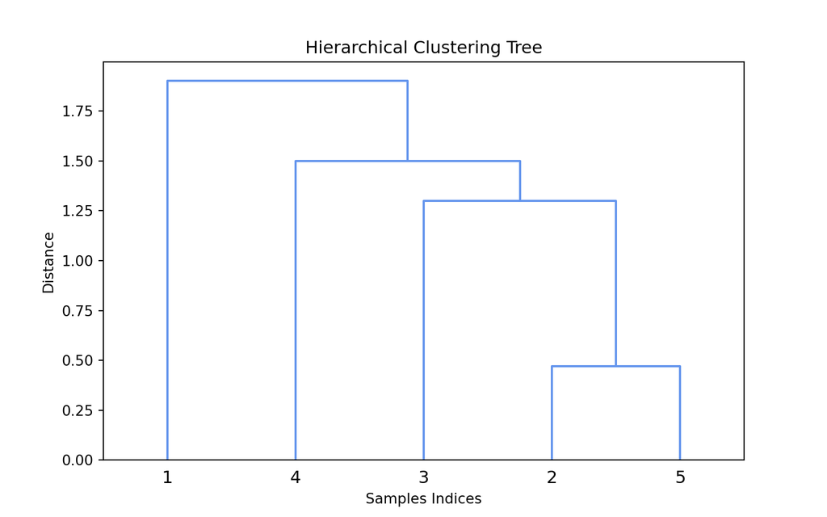

```python
import numpy as np
from scipy.cluster import hierarchy
import matplotlib.pyplot as plt


# lower triangular matrix of distance matrix or upper triangular matrix of distance matrix
half_distance_matrix = np.array([[0, 0, 0, 0, 0],
                                [2.33, 0, 0, 0, 0],
                                [3.15, 1.30, 0, 0, 0],
                                [1.90, 1.50, 3.70, 0, 0],
                                [3.01, 0.47, 1.40, 1.82, 0]]).T

# np.tril_indices(half_distance_matrix.shape[0], -1) returns values' indices of lower triangular matrix without the diagonal values
# np.triu_indices(half_distance_matrix.shape[0], 1) returns values' indices of upper triangular matrix without the diagonal values
# hierarchy.linkage() only receives a compressed 1-dimension array.
compressed_distance_matrix = half_distance_matrix[np.triu_indices(half_distance_matrix.shape[0], 1)]
linkage_matrix = hierarchy.linkage(compressed_distance_matrix, method='single')

# 绘制树状图
plt.close('all') #关闭所有 figure windows
def link_color_func(*args):
    return 'cornflowerblue'
dendrogram = hierarchy.dendrogram(linkage_matrix, labels=['1', '2', '3', '4', '5'], link_color_func=link_color_func)
plt.xlabel('Samples Indices')
plt.ylabel('Distance')
plt.title('Hierarchical Clustering Tree')
plt.show()
```

## Fuzzy clustering using EM